# UDACITY DATA ANALYST PROJECT 2

RMS Titanic was a British passenger liner that sank in the North Atlantic Ocean in the early morning of 15 April 1912 after colliding with an iceberg during her maiden voyage from Southampton, UK, to New York City, US. The sinking resulted in the deaths of more than 1,500 passengers and crew, making it one of the deadliest commercial peacetime maritime disasters in modern history. The RMS Titanic, the largest ship afloat at the time it entered service, was the second of three Olympic class ocean liners operated by the White Star Line, and was built by the Harland and Wolff shipyard in Belfast with Thomas Andrews as her naval architect. Andrews was among those who died in the sinking. On her maiden voyage, she carried 2,224 passengers and crew.

The Titanic Data - Contains demographics and passenger information from 891 of the 2224 passengers and crew on board the Titanic. You can view a description of this dataset on the Kaggle website(https://www.kaggle.com/c/titanic/data), where the data was obtained.

# What factors made people more likely to survive?

```python
import pandas as pd
import numpy as np
import scipy as sp
import matplotlib.pyplot as plt
import seaborn as sns
sns.set(style="darkgrid")

%matplotlib inline
```

*Load the csv file into pandas Dataframe*

```python
titanic_dataframe=pd.read_csv("/home/sanjith/Downloads/titanic_data.csv")
print len(titanic_dataframe)
```

```
891
```

```python
titanic_dataframe.head(3)
```

|  | PassengerId | Survived | Pclass | Name | Sex | Age | SibSp | Parch | Ticket | Fare | Cabin | Embarked |
| --- | --- | --- | --- | --- | --- | --- | --- | --- | --- | --- | --- | --- |
| 0 | 1 | 0 | 3 | Braund, Mr. Owen Harris | male | 22 | 1 | 0 | A/5 21171 | 7.2500 | NaN | S |
| 1 | 2 | 1 | 1 | Cumings, Mrs. John Bradley (Florence Briggs Th... | female | 38 | 1 | 0 | PC 17599 | 71.2833 | C85 | C |
| 2 | 3 | 1 | 3 | Heikkinen, Miss. Laina | female | 26 | 0 | 0 | STON/O2. 3101282 | 7.9250 | NaN | S |

*Let's check the dataset*

Survived Column

```python
print titanic_dataframe[titanic_dataframe.Survived.isnull()]
print titanic_dataframe[(titanic_dataframe.Survived!=0) & (titanic_dataframe.Survived!=1)]
```

```
Empty DataFrame
Columns: [PassengerId, Survived, Pclass, Name, Sex, Age, SibSp, Parch, Ticket, Fare, Cabin, Embarked]
Index: []
Empty DataFrame
Columns: [PassengerId, Survived, Pclass, Name, Sex, Age, SibSp, Parch, Ticket, Fare, Cabin, Embarked]
Index: []
```

Pclass Column

```python
print titanic_dataframe[titanic_dataframe.Pclass.isnull()]
print titanic_dataframe[(titanic_dataframe.Pclass!=1) & (titanic_dataframe.Pclass!=2) & (titanic_dataframe.Pclass!=3)]
```

```
Empty DataFrame
Columns: [PassengerId, Survived, Pclass, Name, Sex, Age, SibSp, Parch, Ticket, Fare, Cabin, Embarked]
Index: []
Empty DataFrame
Columns: [PassengerId, Survived, Pclass, Name, Sex, Age, SibSp, Parch, Ticket, Fare, Cabin, Embarked]
Index: []
```

Age Column

```python
titanic_dataframe[titanic_dataframe.Age.isnull()]
print len(titanic_dataframe[titanic_dataframe.Age.isnull()])
print titanic_dataframe.Age.describe()
```

```
177
count    714.000000
mean      29.699118
std       14.526497
min        0.420000
25%       20.125000
50%       28.000000
75%       38.000000
max       80.000000
Name: Age, dtype: float64
```

There are 177 rows with missing Age data.The minimum and maximum values for age are seem to be valid.

SibSp Column

```python
print titanic_dataframe[titanic_dataframe.SibSp.isnull()]
```

```
Empty DataFrame
Columns: [PassengerId, Survived, Pclass, Name, Sex, Age, SibSp, Parch, Ticket, Fare, Cabin, Embarked]
Index: []
```

Parch Column

```python
print titanic_dataframe[titanic_dataframe.Parch.isnull()]
```

```
Empty DataFrame
Columns: [PassengerId, Survived, Pclass, Name, Sex, Age, SibSp, Parch, Ticket, Fare, Cabin, Embarked]
Index: []
```

Fare Column

```python
print titanic_dataframe[titanic_dataframe.Fare.isnull()]
print titanic_dataframe.Fare.describe()
```

```
Empty DataFrame
Columns: [PassengerId, Survived, Pclass, Name, Sex, Age, SibSp, Parch, Ticket, Fare, Cabin, Embarked]
Index: []
count    891.000000
mean      32.204208
std       49.693429
min        0.000000
25%        7.910400
50%       14.454200
75%       31.000000
max      512.329200
Name: Fare, dtype: float64
```

The minimum fare is 0.Which is odd.Also the maximum fare is 512 which is also odd.

So far we have found that Age column has null values in it.Lets drop all the rows where age is null.(We have ignored other columns like Ticket and Cabin cause they are not important.)

Let's drop all the rows where Age value is null.

```python
titanic_df=titanic_dataframe.dropna(subset=['Age'])
print len(titanic_df)
titanic_df.head(3)
```

```
714
```

|  | PassengerId | Survived | Pclass | Name | Sex | Age | SibSp | Parch | Ticket | Fare | Cabin | Embarked |
| --- | --- | --- | --- | --- | --- | --- | --- | --- | --- | --- | --- | --- |
| 0 | 1 | 0 | 3 | Braund, Mr. Owen Harris | male | 22 | 1 | 0 | A/5 21171 | 7.2500 | NaN | S |
| 1 | 2 | 1 | 1 | Cumings, Mrs. John Bradley (Florence Briggs Th... | female | 38 | 1 | 0 | PC 17599 | 71.2833 | C85 | C |
| 2 | 3 | 1 | 3 | Heikkinen, Miss. Laina | female | 26 | 0 | 0 | STON/O2. 3101282 | 7.9250 | NaN | S |

Now we have a clean dataset.

*Creating a new column titanic_dataframe['Category']*(To have a better understanding)

```python
#creating an empty list
listChild=[]
for x , y in zip(titanic_df.Age ,titanic_df.Sex):
        if x<10.0:
            listChild.append('child')
        else:
            listChild.append(y)


titanic_df['Category']=listChild
titanic_df.head(3)
```

|  | PassengerId | Survived | Pclass | Name | Sex | Age | SibSp | Parch | Ticket | Fare | Cabin | Embarked | Category |
| --- | --- | --- | --- | --- | --- | --- | --- | --- | --- | --- | --- | --- | --- |
| 0 | 1 | 0 | 3 | Braund, Mr. Owen Harris | male | 22 | 1 | 0 | A/5 21171 | 7.2500 | NaN | S | male |
| 1 | 2 | 1 | 1 | Cumings, Mrs. John Bradley (Florence Briggs Th... | female | 38 | 1 | 0 | PC 17599 | 71.2833 | C85 | C | female |
| 2 | 3 | 1 | 3 | Heikkinen, Miss. Laina | female | 26 | 0 | 0 | STON/O2. 3101282 | 7.9250 | NaN | S | female |

Here we have considered anyone with age under 10 as a child.

*Total number of Males ,females and children passengers.*

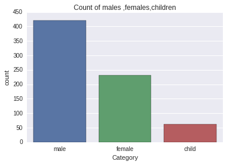

```python
ax = sns.countplot(x="Category", data=titanic_df)
ax.set_title("Count of males ,females,children")
```

As we can see ,There are majority male passengers.And around 60-70 children.Remaining are females.

*Age of the passengers*

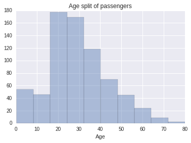

```python
ax = sns.distplot(titanic_df.Age,bins=10,kde=False)
ax.set_title("Age split of passengers")
```